# Analisis Proyecto

CI0131 - Diseño de Experimentos I Ciclo 2025

Estudiante 1: Archibald Carrion

Estudiante 2: Milton Sojo

Estudiante 3: Brandon Trigueros

Estudiante 4: David Gonzalez

2025-06-11

```r
# Configuración inicial del documento
knitr::opts_chunk$set(echo = TRUE, warning = FALSE, message = FALSE)
```

## Preparación de datos

En esta sección se preparan los datos para el análisis: cargamos las bibliotecas necesarias, importamos el archivo CSV y configuramos las variables del experimento.

```r
# Carga de librerías necesarias para el análisis
library(dplyr)
library(ggplot2)
library(readr)
```

```r
# Lectura del archivo CSV con los resultados del benchmark
df = (read.csv("../data/execution/combined_data.csv", header=T, encoding = "UTF-8"))

# Renombra y convierte variables
df <- df %>%
  mutate(
    response    = avg_time_sec,
    architecture= factor(architecture, levels = c("intel","ryzen")),
    compiler    = factor(compiler,   levels = c("clang","gcc")),
    obs         = row_number()           # índice de observación
  )
```

## Aleatorización de datos

Para garantizar la validez del análisis, aleatorizamos el orden de las observaciones para evitar efectos sistemáticos relacionados con el momento en que se tomaron las mediciones.

```r
# Barajamos todo el dataframe para aleatorización real
set.seed(1234)
df <- df %>%
  sample_frac(1) %>%           # baraja todas las filas
  mutate(
    obs           = row_number(),            # índice de observación aleatorio
    time_observed = cumsum(response)         # tiempo acumulado desde t0 = 0
  )
```

Visualización de las primeras filas del dataframe después de la aleatorización:

```r
# Muestra las primeras filas del dataframe aleatorizado
head(df)
```

|  | filename | exec_size | max_mem_kb | avg_time_sec | architecture | compiler | response | obs | time_observed |
| --- | --- | --- | --- | --- | --- | --- | --- | --- | --- |
| 1 | 199.c | 16K | 5468 | 0.022595701 | intel | clang | 0.022595701 | 1 | 0.02259570 |
| 2 | 123.c | 16K | 1700 | 0.001143905 | intel | clang | 0.001143905 | 2 | 0.02373961 |
| 3 | 100.c | 16K | 1424 | 0.001208323 | intel | gcc | 0.001208323 | 3 | 0.02494793 |
| 4 | 135.c | 16K | 9188 | 0.003418541 | intel | clang | 0.003418541 | 4 | 0.02836647 |
| 5 | 112.c | 16K | 8960 | 0.398790708 | ryzen | gcc | 0.398790708 | 5 | 0.42715718 |
| 6 | 60.c | 16K | 1600 | 0.000991200 | intel | gcc | 0.000991200 | 6 | 0.42814838 |

## Estadísticas descriptivas globales

Calculamos estadísticas básicas para toda la muestra para entender la distribución general de los tiempos de ejecución.

```r
# Cálculo de medidas estadísticas básicas para toda la muestra
global_stats <- df %>%
  summarise(
    mean    = mean(response),
    variance= var(response),
    sd      = sd(response),
    min     = min(response),
    Q1      = quantile(response, 0.25),
    median  = median(response),
    Q3      = quantile(response, 0.75),
    max     = max(response)
  )

print(global_stats)
```

```
##         mean   variance        sd         min          Q1      median
## 1 0.02160954 0.01728927 0.1314887 -0.05047217 0.001311686 0.009385747
##           Q3      max
## 1 0.01051103 2.597234
```

Las estadísticas muestran la distribución de los tiempos de ejecución en la muestra completa, observándose un tiempo medio de ejecución de 0.0216 segundos con una desviación estándar de 0.1315 segundos.

- **Media**: ∼0.022 s, pero la **mediana** es mucho menor (∼0.009 s), lo que señala una cola larga de valores grandes.
- El **mínimo negativo** (−0.050 s) es un artefacto de medición o un error que habría que depurar.
- El **IQR** (desde Q1 hasta Q3) cubre valores muy bajos (1–10 ms), mostrando que la mayoría de corridas son ultrarrápidas.

## Visualizaciones exploratorias globales

### Boxplot de tiempos de ejecución

El siguiente boxplot muestra la distribución general de los tiempos de ejecución utilizando una escala logarítmica para manejar los outliers.

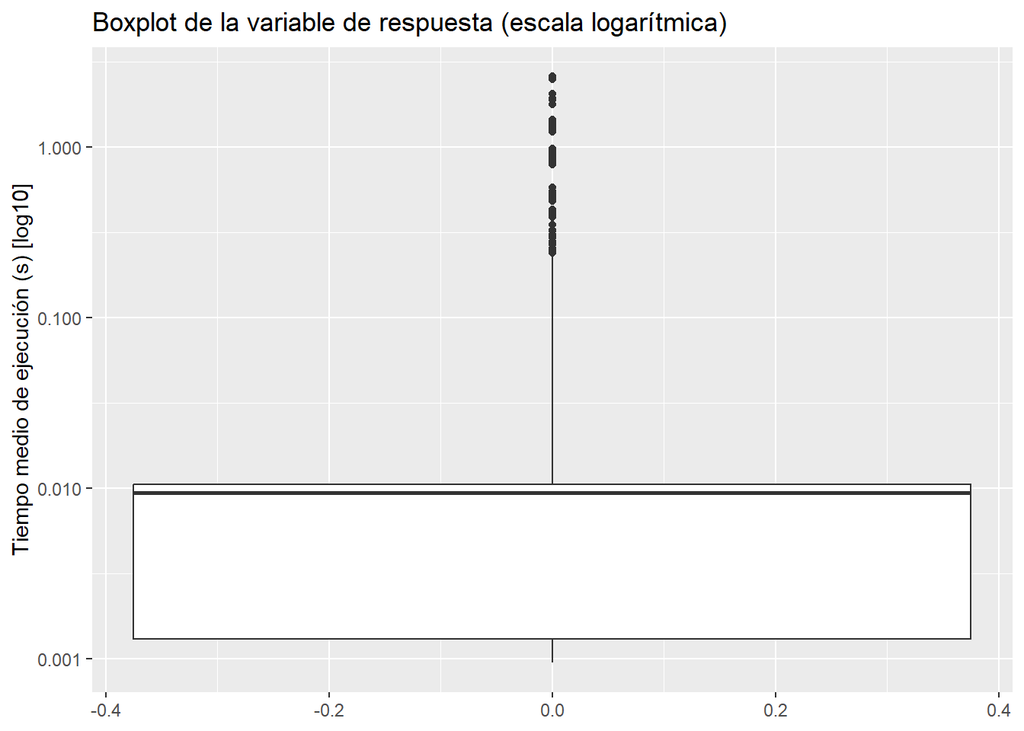

```r
# Boxplot global con escala logarítmica
ggplot(df, aes(y = response)) +
  geom_boxplot() +
  scale_y_log10() +  # Escala logarítmica para mejor visualización
  labs(
    title = "Boxplot de la variable de respuesta (escala logarítmica)",
    y     = "Tiempo medio de ejecución (s) [log10]"
  )
```

### Histograma de tiempos de ejecución

El histograma permite visualizar la distribución de frecuencias de los tiempos de ejecución usando escala logarítmica.

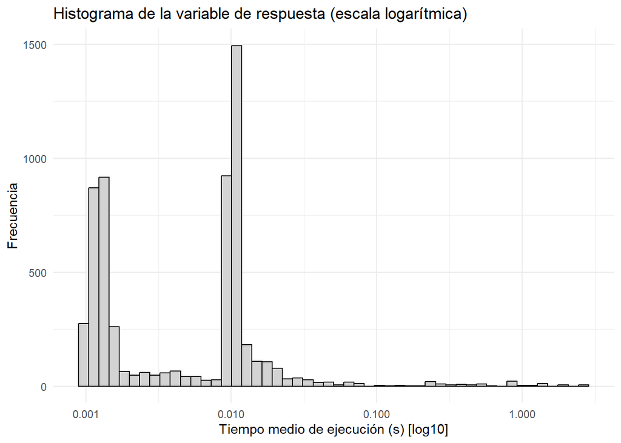

```r
# Histograma con escala logarítmica
ggplot(df, aes(x = response)) +
  geom_histogram(bins = 50, color = "black", fill = "lightgray") +
  scale_x_log10() +  # Escala logarítmica para mejor visualización
  labs(
    title = "Histograma de la variable de respuesta (escala logarítmica)",
    x     = "Tiempo medio de ejecución (s) [log10]",
    y     = "Frecuencia"
  ) +
  theme_minimal()
```

**Distribución fuertemente sesgada:**

Pico con más frecuencia en la zona de 10⁻³–10⁻² s.

Caída rápida hacia tiempos más largos, con una larga cola de bajas frecuencias hasta ∼10⁰ s.

El histograma confirma visualmente esa asimetría y la presencia de valores extremos.

**Gráfico comparativo por compilador:**

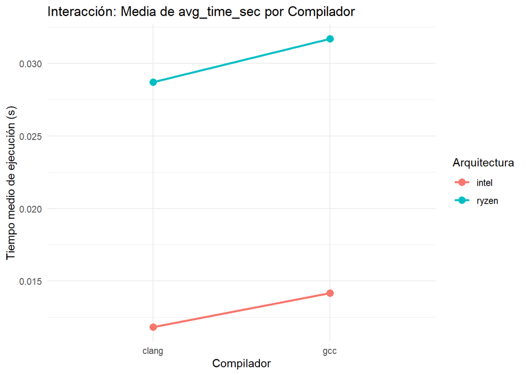

```r
library(ggplot2)

# Interacción: Media de response por compilador, coloreado por arquitectura
ggplot(df, aes(x = compiler, y = response, color = architecture, group = architecture)) +
  stat_summary(fun = mean, geom = "point", size = 3) +
  stat_summary(fun = mean, geom = "line", size = 1) +
  labs(
    title = "Interacción: Media de avg_time_sec por Compilador",
    x     = "Compilador",
    y     = "Tiempo medio de ejecución (s)",
    color = "Arquitectura"
  ) +
  theme_minimal()
```

**Gráfico comparativo por arquitectura:**

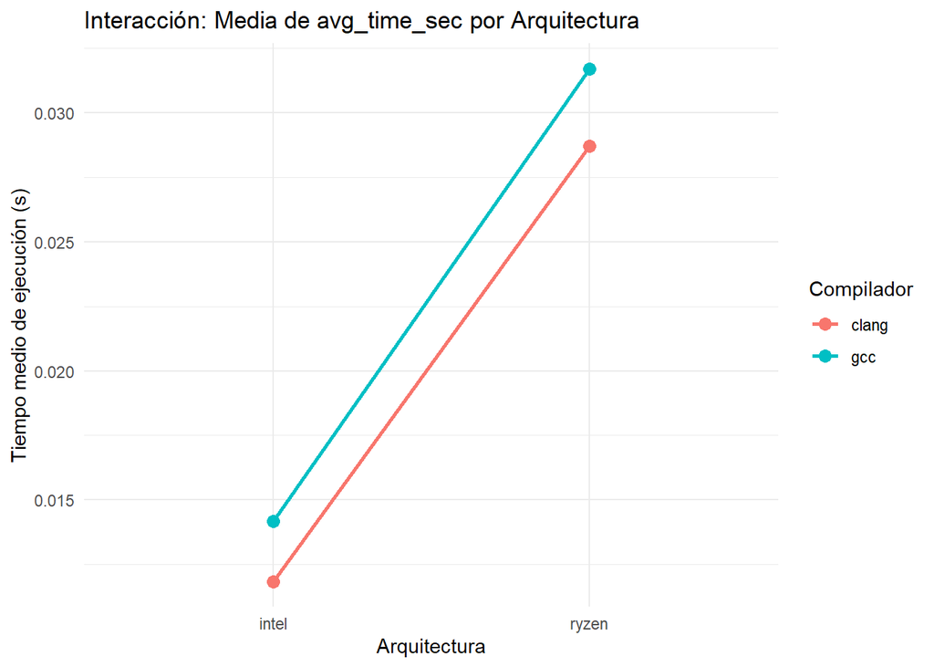

```r
# Interacción: Media de response por arquitectura, coloreado por compilador
ggplot(df, aes(x = architecture, y = response, color = compiler, group = compiler)) +
  stat_summary(fun = mean, geom = "point", size = 3) +
  stat_summary(fun = mean, geom = "line", size = 1) +
  labs(
    title = "Interacción: Media de avg_time_sec por Arquitectura",
    x     = "Arquitectura",
    y     = "Tiempo medio de ejecución (s)",
    color = "Compilador"
  ) +
  theme_minimal()
```

Indica que los efectos de los factores son **consistentes** a través de los niveles del otro factor

### Creación de variable de tratamiento

Para análisis posterior, creamos una variable que combine arquitectura y compilador.

```r
# Creamos la variable treatment para usarla en los gráficos
df <- df %>%
  mutate(treatment = interaction(architecture, compiler, sep = " × "))
```

### Serie temporal de mediciones

Este gráfico muestra cómo varían los tiempos de ejecución a lo largo del tiempo observado, diferenciando por tratamiento.

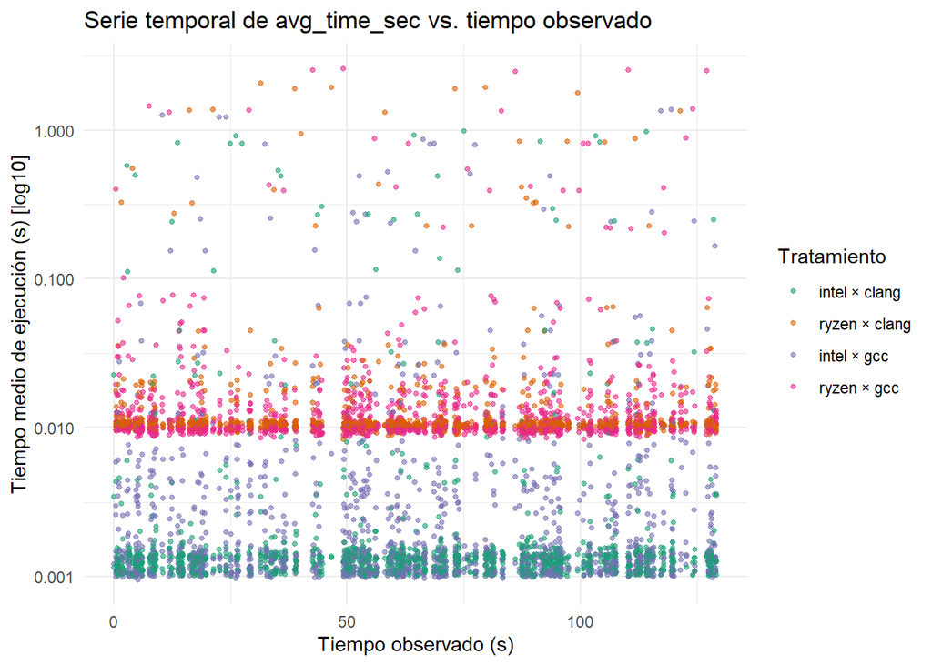

```r
# Serie temporal de tiempos de ejecución
ggplot(df, aes(x = time_observed, y = response, color = treatment)) +
  geom_point(size = 1, alpha = 0.6) +
  scale_color_brewer(palette = "Dark2") +
  scale_y_log10() +
  labs(
    title = "Serie temporal de avg_time_sec vs. tiempo observado",
    x     = "Tiempo observado (s)",
    y     = "Tiempo medio de ejecución (s) [log10]",
    color = "Tratamiento"
  ) +
  theme_minimal()
```

**Cada punto es una corrida coloreada por tratamiento.**

**Se observa claramente la separación horizontal:**

Ryzen entre ∼10⁻² y 10⁻¹ s (o más).

Esto refleja el efecto real de arquitectura sobre el rendimiento, no un fallo de aleatorización.

### Verificación de aleatorización

Este gráfico permite verificar que la aleatorización ha funcionado correctamente, mostrando la distribución de tratamientos en el orden de observación.

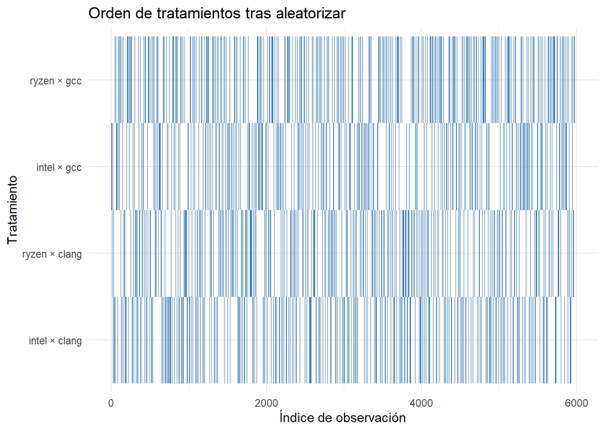

```r
# Gráfico para verificar la aleatorización
ggplot(df, aes(x = obs, y = treatment)) +
  geom_tile(fill = "steelblue") +
  labs(
    title = "Orden de tratamientos tras aleatorizar",
    x     = "Índice de observación",
    y     = "Tratamiento"
  ) +
  theme_minimal()
```

Para verificar la aleatorización generamos un gráfico de “rayas” en el que cada raya vertical representa una corrida. Si la aleatorización fuese deficiente, veríamos bloques de un solo tratamiento juntos (por ejemplo, todas las corridas de intel×clang seguidas, luego las de ryzen×gcc, etc.).

- El gráfico de “rayas” muestra cada tratamiento repartido de modo uniforme sobre el eje X (índice de observación).
- No hay bloques continuos de un solo color: cada uno de los cuatro tratamientos aparece intercalado a lo largo de todo el rango, lo que confirma que el orden está bien aleatorizado.

## Análisis por factores individuales

### Estadísticas por arquitectura

Analizamos las diferencias en tiempos de ejecución entre las arquitecturas Intel y Ryzen.

```r
# Estadísticas descriptivas agrupadas por tipo de arquitectura
arch_stats <- df %>%
  group_by(architecture) %>%
  summarise(
    n       = n(),
    mean    = mean(response),
    variance= var(response),
    sd      = sd(response),
    min     = min(response),
    Q1      = quantile(response, 0.25),
    median  = median(response),
    Q3      = quantile(response, 0.75),
    max     = max(response)
  )
print(arch_stats)
```

```
## # A tibble: 2 × 10
##   architecture     n   mean variance     sd       min      Q1  median      Q3
##   <fct>        <int>  <dbl>    <dbl>  <dbl>     <dbl>   <dbl>   <dbl>   <dbl>
## 1 intel         2990 0.0130  0.00778 0.0882  0.000952 0.00111 0.00131 0.00158
## 2 ryzen         2990 0.0302  0.0267  0.163  -0.0505   0.00990 0.0104  0.0111
## # ℹ 1 more variable: max <dbl>
```

Las estadísticas muestran diferencias en el rendimiento medio entre las arquitecturas Intel y Ryzen, con Intel mostrando un tiempo medio de 0.013 segundos frente a Ryzen con 0.0302 segundos.

- Intel es, de media, **∼2.3× más rápido** que Ryzen.
- La variabilidad (sd) también es menor en Intel, indicando ejecuciones más consistentes.

### Estadísticas por compilador

Comparamos el rendimiento entre los compiladores GCC y Clang.

```r
# Estadísticas descriptivas agrupadas por tipo de compilador
comp_stats <- df %>%
  group_by(compiler) %>%
  summarise(
    n       = n(),
    mean    = mean(response),
    variance= var(response),
    sd      = sd(response),
    min     = min(response),
    Q1      = quantile(response, 0.25),
    median  = median(response),
    Q3      = quantile(response, 0.75),
    max     = max(response)
  )
print(comp_stats)
```

```
## # A tibble: 2 × 10
##   compiler     n   mean variance    sd       min      Q1  median     Q3   max
##   <fct>    <int>  <dbl>    <dbl> <dbl>     <dbl>   <dbl>   <dbl>  <dbl> <dbl>
## 1 clang     2980 0.0203   0.0147 0.121 -0.0505   0.00130 0.00965 0.0106  2.06
## 2 gcc       3000 0.0229   0.0199 0.141  0.000952 0.00134 0.00930 0.0103  2.60
```

Los resultados muestran diferencias en el rendimiento entre los compiladores, con Clang mostrando un tiempo medio de 0.0203 segundos frente a GCC con 0.0229 segundos.

**Clang rinde ligeramente mejor (∼11% más rápido en media) y con menor dispersión.**

## Análisis de interacciones entre factores

Examinamos cómo interactúan la arquitectura y el compilador.

```r
# Estadísticas por combinación de factores
treat_stats <- df %>%
  group_by(architecture, compiler) %>%
  summarise(
    n       = n(),
    mean    = mean(response),
    variance= var(response),
    sd      = sd(response),
    min     = min(response),
    Q1      = quantile(response, 0.25),
    median  = median(response),
    Q3      = quantile(response, 0.75),
    max     = max(response)
  )
print(treat_stats)
```

```
## # A tibble: 4 × 11
## # Groups:   architecture [2]
##   architecture compiler     n   mean variance     sd       min      Q1  median
##   <fct>        <fct>    <int>  <dbl>    <dbl>  <dbl>     <dbl>   <dbl>   <dbl>
## 1 intel        clang     1490 0.0118  0.00657 0.0811  0.000985 0.00113 0.00130
## 2 intel        gcc       1500 0.0142  0.00898 0.0948  0.000952 0.00110 0.00134
## 3 ryzen        clang     1490 0.0287  0.0227  0.151  -0.0505   0.0102  0.0105
## 4 ryzen        gcc       1500 0.0317  0.0306  0.175   0.00839  0.00967 0.0101
## # ℹ 2 more variables: Q3 <dbl>, max <dbl>
```

El análisis combinado revela cómo cada compilador rinde en cada arquitectura, mostrando posibles interacciones entre estos factores.

## Visualizaciones comparativas

### Comparación por arquitectura

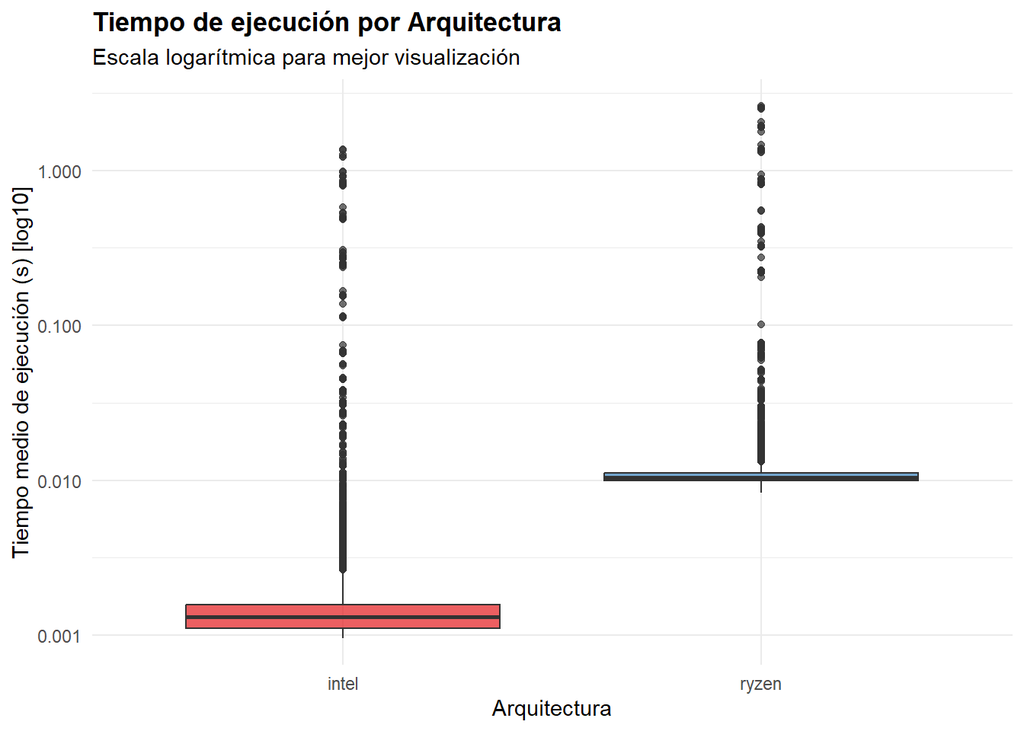

```r
# Boxplot comparativo por arquitectura
ggplot(df, aes(x = architecture, y = response, fill = architecture)) +
  geom_boxplot(alpha = 0.7) +
  scale_y_log10() +
  scale_fill_brewer(palette = "Set1") +
  labs(
    title = "Tiempo de ejecución por Arquitectura",
    subtitle = "Escala logarítmica para mejor visualización",
    x = "Arquitectura",
    y = "Tiempo medio de ejecución (s) [log10]"
  ) +
  theme_minimal() +
  theme(
    plot.title = element_text(face = "bold"),
    legend.position = "none"
  )
```

El boxplot muestra visualmente las diferencias en distribución y variabilidad de los tiempos de ejecución entre las arquitecturas Intel y Ryzen.

### Comparación por compilador

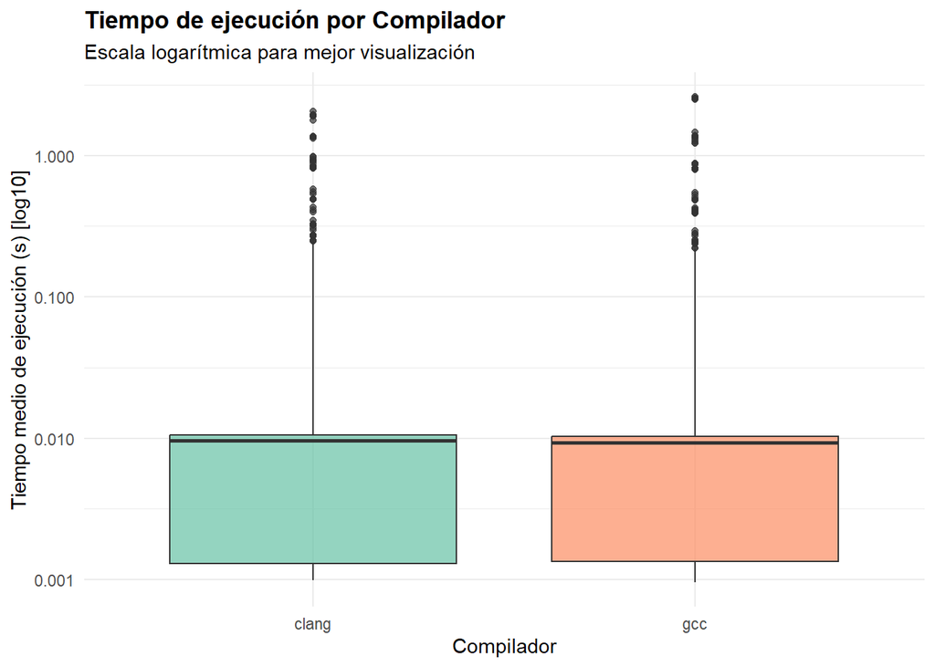

```r
# Boxplot comparativo por compilador
ggplot(df, aes(x = compiler, y = response, fill = compiler)) +
  geom_boxplot(alpha = 0.7) +
  scale_y_log10() +
  scale_fill_brewer(palette = "Set2") +
  labs(
    title = "Tiempo de ejecución por Compilador",
    subtitle = "Escala logarítmica para mejor visualización",
    x = "Compilador",
    y = "Tiempo medio de ejecución (s) [log10]"
  ) +
  theme_minimal() +
  theme(
    plot.title = element_text(face = "bold"),
    legend.position = "none"
  )
```

Este boxplot permite visualizar las diferencias de rendimiento entre los compiladores Clang y GCC.

### Comparación de todos los tratamientos

Finalmente, comparamos el rendimiento de todas las combinaciones de arquitectura y compilador.

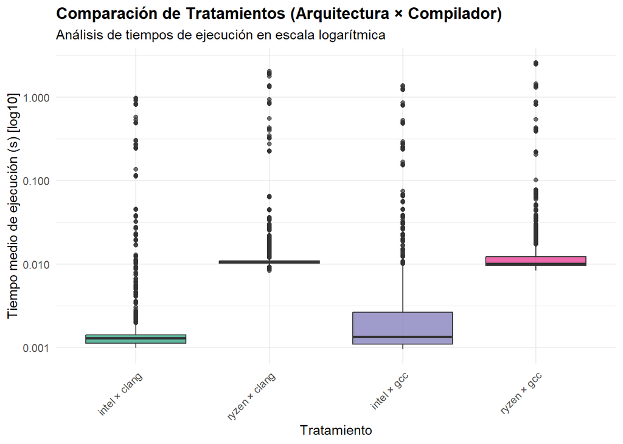

```r
# Boxplot comparativo de todos los tratamientos
ggplot(df, aes(x = treatment, y = response, fill = treatment)) +
  geom_boxplot(alpha = 0.7) +
  scale_y_log10() +
  scale_fill_brewer(palette = "Dark2") +
  labs(
    title = "Comparación de Tratamientos (Arquitectura × Compilador)",
    subtitle = "Análisis de tiempos de ejecución en escala logarítmica",
    x = "Tratamiento",
    y = "Tiempo medio de ejecución (s) [log10]"
  ) +
  theme_minimal() +
  theme(
    plot.title = element_text(face = "bold"),
    axis.text.x = element_text(angle = 45, hjust = 1),
    legend.position = "none"
  )
```

Este gráfico permite visualizar y comparar el rendimiento de cada combinación específica de arquitectura y compilador, revelando patrones que pueden no ser evidentes al analizar cada factor por separado.

Esta vista conjunta resalta cómo la combinación de factores impacta el tiempo de ejecución y permite planificar optimizaciones.